# Better Know Selection

Jeffrey A. Walker

2024-02-06

From Computing Consequences 6.3 (and lecture)

$$p'_{1} = \frac{p^2_{1}w_{11} +
p_{1}p_{2}w_{12}}{\overline{w}}$$

$$p'_{2} = \frac{p^2_{2}w_{22} +
p_{1}p_{2}w_{12}}{\overline{w}}$$

$$\overline{w} = p^2_{1}w_{11} +
2p_{1}p_{1}w_{12}+ p^2_{2}w_{22}$$

# Create Google Sheet that looks like this:

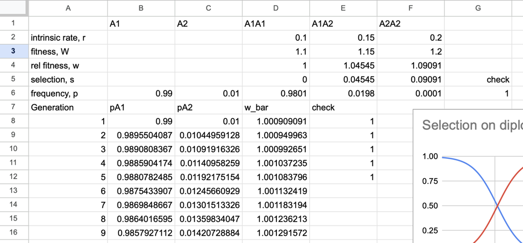

1. Rows 1-6 specify the **parameters of the model**. This is the parameter table.
   - Columns B and C are columns for the A1 and A2 alleles
   - Columns D-F are columns for the three genotypes
2. Row 7-507 are the simulation
3. The intrinsic rate (r) is not a formula – you just insert meaningful values to study the consequence
4. Fitness W is a formula. Insert this formula to get a value.
5. relative fitness w is a formula. Insert this formula to get a value.
6. frequency p for allele A1 is not a formula – you just insert a meaningful value.
7. frequency p for allele A2 and all genotype frequencies are formulas. Insert these.
8. Create rows for Generation 1-500 in the cells under “Generation”. A formula after the first value is helps.
9. The values in Generation 1, for the frequency of alleles 1 and 2 should equal the values in your parameter table. Do not hardcode but use a formula.
10. Insert the formula for mean fitness $\overline{w}$ in Generation 1.
11. Now in Generation 2, insert the formula for the allele frequencies given the values in Generation 1. Then copy down the formula for mean fitness for Generation 2.
12. Copy the three values in Generation 2 down to Generation 500.

Now you have a simulator!